# Régression simple - II

Paul Bastide

2026-09-29

# What we know

## Model

$$y_i = \beta_0 + \beta_1 x_i + \epsilon_i, \quad \forall 1 \leq i \leq n$$

- $y_i$: quantitative response for $i$ (`sales`)
- $x_i$: quantitative predicting variable for $i$ (`TV`)
- $\epsilon_i$: “error” for $i$
  - **random variable**
  - (H1) $\mathbb{E}[\epsilon_i] = 0$ for all $i$ (centered)
  - (H2) $\mathbb{Var}[\epsilon_i] = \sigma^2$ for all $i$ (identical variance)
  - (H3) $\mathbb{Cov}[\epsilon_i; \epsilon_j] = 0$ for all $i \neq j$ (uncorrelated)
- **Note**: Assumptions on first and second moments *only*.

## OLS Estimators

$$(\hat{\beta}_0, \hat{\beta}_1)
= \underset{(\beta_0, \beta_1) \in \mathbb{R}^2}{\operatorname{argmin}}
\left\{
\sum_{i = 1}^n (y_i - \beta_0 - \beta_1 x_i)^2
\right\}$$

- Properties on the first and second moments *only*.

$$\begin{aligned}
\hat{\beta}_0
&= \bar{y} - \hat{\beta}_1\bar{x}
&
\hat{\beta}_1
&= \frac{s_{\mathbf{y},\mathbf{x}}^2}{s_{\mathbf{x}}^2}
\\
\mathbb{E}[\hat{\beta}_0] &= \beta_0
&
\mathbb{E}[\hat{\beta}_1] &= \beta_1
\\
\mathbb{Var}[\hat{\beta}_0]
&= \frac{\sigma^2}{n} \left( 1 + \frac{\bar{x}^2}{s_{\mathbf{x}}^2} \right)
&
\mathbb{Var}[\hat{\beta}_1]
&= \frac{\sigma^2}{n}\frac{1}{s_{\mathbf{x}}^2}
\\
\mathbb{Cov}[\hat{\beta}_0; \hat{\beta}_1]
&= - \frac{\sigma^2}{n} \frac{\bar{x}}{s_{\mathbf{x}}^2}
\end{aligned}$$

## Questions

- Confidence interval for $(\hat{\beta}_0, \hat{\beta}_1)$ ?
- Can we test $\hat{\beta}_1 = 0$ (i.e. no linear trend) ?
- Assumptions on the moments are not enough.  
  $\hookrightarrow$ We need assumptions on the *specific distribution* of the $\epsilon_i$.
- Most common assumption: $\epsilon_i$ are **Gaussian**.

# Gaussian Model

## Gaussian Model

$$y_i = \beta_0 + \beta_1 x_i + \epsilon_i, \quad \forall 1 \leq i \leq n$$

- $y_i$: quantitative response for $i$ (`sales`)
- $x_i$: quantitative predicting variable for $i$ (`TV`)
- $\epsilon_i$: “error” for $i$
  - random variable (r.v.)
  - independent, **identically distributed** (**iid**), **Gaussian**
  - Centered, with variance $\sigma^2$:

$$\epsilon_i
\underset{\text{iid}}{\operatorname{\sim}}
\mathcal{N}(0, \sigma^2)
\quad
\text{for}
\quad
1 \leq i \leq n$$

- [**Note** (H1), (H2) and (H3) are still verified.]

## Reminder: Gaussian Distribution 1/2

Let $X$ be a Gaussian r.v. with expectation $\mu$ and variance $\sigma^2$:
$$X \sim \mathcal{N}(\mu, \sigma^2).$$

It admits a probability density function (pdf):
$$f(x) = \frac{1}{\sqrt{2\pi\sigma^2}}\exp\left(-\frac{(x - \mu)^2}{2\sigma^2}\right)
\quad
\forall x \in \mathbb{R},$$

And a characteristic function:
$$\phi_{X}(t) = \mathbb{E}[e^{itX}] = e^{i\mu t - \frac{\sigma^2 t^2}{2}}
\quad
\forall t \in \mathbb{R}.$$

## Reminder: Gaussian Distribution 2/2

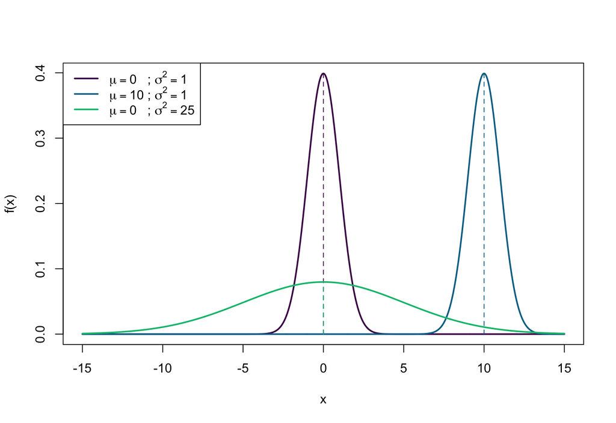

## Distribution of $\mathbf{y}$

- Model:
  $$y_i = \beta_0 + \beta_1 x_i + \epsilon_i
  \quad
  \text{with}
  \quad
  \epsilon_i
  \underset{\text{iid}}{\operatorname{\sim}}
  \mathcal{N}(0, \sigma^2)
  \quad
  \text{for}
  \quad
  1 \leq i \leq n$$
- Distribution of $y_i$ ?

## Reminder: Linear function of a Gaussian

If $X \sim \mathcal{N}(\mu, \sigma^2)$, then for any $(a, b) \in \mathbb{R}^2$,
$$Y = aX + b \sim \mathcal{N}(a\mu + b, a^2\sigma^2).$$

- **Proof**: Exercise.  
  [Hint: use the characteristic function.]
- $y_i = \beta_0 + \beta_1 x_i + \epsilon_i$  
  Apply the property with $a = 1$ and $b = \beta_0 + \beta_1 x_i$.  
  [Reminder: $x_i$ are assumed to be non random here.]

## Distribution of $\mathbf{y}$

- Model:
  $$y_i = \beta_0 + \beta_1 x_i + \epsilon_i
  \quad
  \text{with}
  \quad
  \epsilon_i
  \underset{\text{iid}}{\operatorname{\sim}}
  \mathcal{N}(0, \sigma^2)
  \quad
  \text{for}
  \quad
  1 \leq i \leq n$$
- Distribution of $y_i$:
  $$y_i
  \underset{\text{iid}}{\operatorname{\sim}}
  \mathcal{N}(\beta_0 + \beta_1 x_i, \sigma^2)
  \quad
  \text{for}
  \quad
  1 \leq i \leq n$$
- **Question**: What is the *likelihood* of $\mathbf{y} = (y_1, \dotsc, y_n)^T$ ?

# Maximum Likelihood Estimators

## Reminder: Likelihood

If $X$ is a rv that admits a density $f_{\theta}$ that depends on a parameter $\theta$, then the likelihood function is the density, seen as a function of $\theta$ given an outcome $X = x$:
$$\theta \mapsto L(\theta | x) = f_{\theta}(x).$$

**Example**:
Assume that we observe one realization $x$ of a Gaussian random variable $X$, with unknown expectation $\mu$, but known variance $\sigma^2 = 1$.
Then the Likelihood of the observation $x_{obs}$ is the function:
$$\mu \to \frac{1}{\sqrt{2\pi\sigma^2}}\exp\left(-\frac{(x_{obs} - \mu)^2}{2\sigma^2}\right).$$

$\to$ [Seeing Theory](https://seeing-theory.brown.edu/bayesian-inference/index.html#section2)

## Reminder: Maximum Likelihood 1/2

The Maximum Likelihood (ML) estimator $\hat{\theta}$ of the parameter $\theta$ is the one that maximizes the likelihood function in $\theta$, given an observation $x$:

$$\hat{\theta} = \underset{\theta}{\operatorname{argmax}} L(\theta | x).$$
**Example**:
Let $x_{obs}$ be one realization of a Gaussian r.v. $X$, with unknown expectation $\mu$, but known variance $\sigma^2 = 1$.
Then the ML estimator $\hat{\mu}$ of $\mu$ is:
$$\hat{\mu} = \underset{\mu \in \mathbb{R}}{\operatorname{argmax}} \frac{1}{\sqrt{2\pi\sigma^2}}\exp\left(-\frac{(x_{obs} - \mu)^2}{2\sigma^2}\right).$$

## Reminder: Maximum Likelihood 2/2

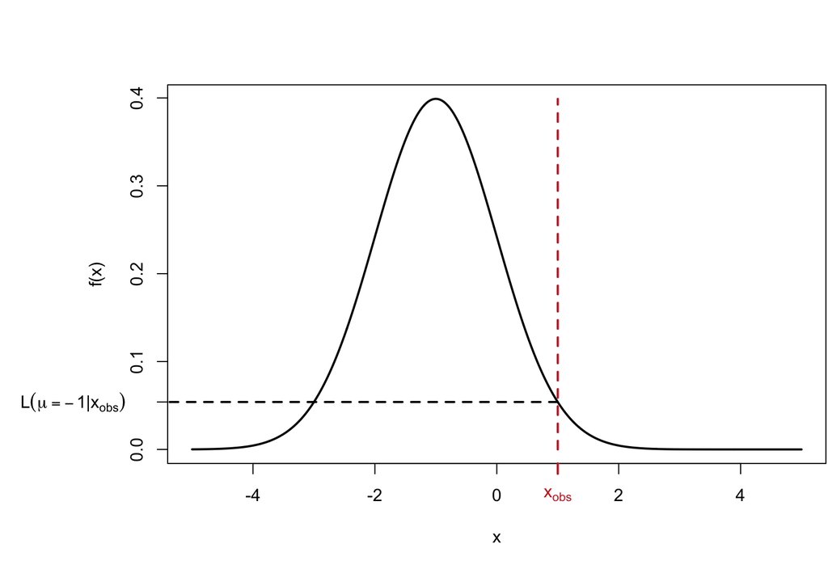

## Reminder: Maximum Likelihood 2/2

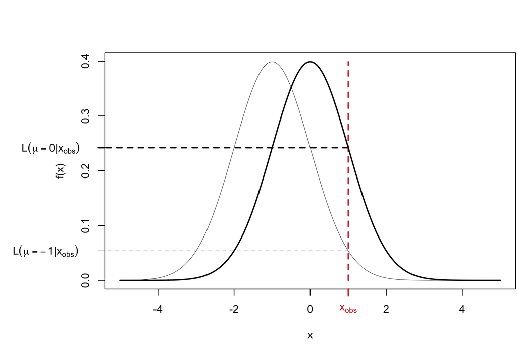

## Reminder: Maximum Likelihood 2/2

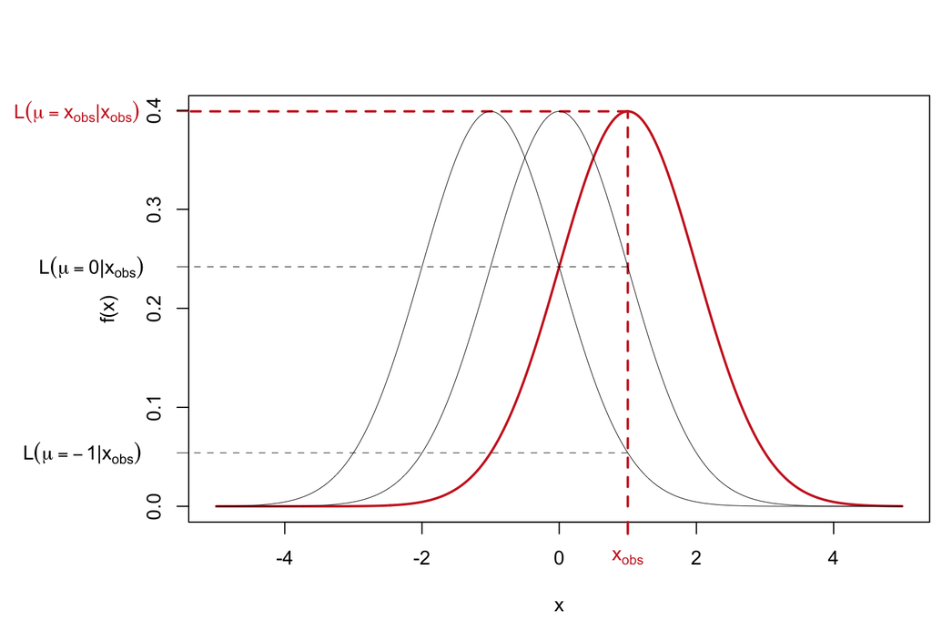

## Likelihood of $\mathbf{y}$

Distribution of $y_i$:
$$y_i
\underset{\text{iid}}{\operatorname{\sim}}
\mathcal{N}(\beta_0 + \beta_1 x_i, \sigma^2)
\quad
\text{for}
\quad
1 \leq i \leq n$$

Likelihood of $\mathbf{y} = (y_1, \dotsc, y_n)^T$:

$$\begin{aligned}
&L(\beta_0, \beta_1, \sigma^2 | y_1, \dotsc, y_n)
= \prod_{i = 1}^n L(\beta_0, \beta_1, \sigma^2 | y_i) & [ind.]\\
\end{aligned}$$

and
$$\begin{aligned}
L(\beta_0, \beta_1, \sigma^2 | y_i)
= \cdots
\end{aligned}$$

## Likelihood of $\mathbf{y}$

Distribution of $y_i$:
$$y_i
\underset{\text{iid}}{\operatorname{\sim}}
\mathcal{N}(\beta_0 + \beta_1 x_i, \sigma^2)
\quad
\text{for}
\quad
1 \leq i \leq n$$

Likelihood of $\mathbf{y} = (y_1, \dotsc, y_n)^T$:

$$\begin{aligned}
&L(\beta_0, \beta_1, \sigma^2 | y_1, \dotsc, y_n)
= \prod_{i = 1}^n L(\beta_0, \beta_1, \sigma^2 | y_i) & [ind.]\\
\end{aligned}$$

and
$$\begin{aligned}
L(\beta_0, \beta_1, \sigma^2 | y_i)
= \frac{1}{\sqrt{2\pi\sigma^2}}\exp\left(-\frac{(y_i - \beta_0 - \beta_1 x_i)^2}{2\sigma^2}\right)
\end{aligned}$$

## Likelihood of $\mathbf{y}$

- Likelihood of $\mathbf{y} = (y_1, \dotsc, y_n)^T$:
  $$\begin{aligned}
  L(\beta_0, \beta_1, \sigma^2 | y_1, \dotsc, y_n)
  &= \prod_{i = 1}^n L(\beta_0, \beta_1, \sigma^2 | y_i)\\
  &= \prod_{i = 1}^n \frac{1}{\sqrt{2\pi\sigma^2}}\exp\left(-\frac{(y_i - \beta_0 - \beta_1 x_i)^2}{2\sigma^2}\right)\\
  &= \frac{1}{\left(\sqrt{2\pi\sigma^2}\right)^n}\exp\left(-\frac{1}{2\sigma^2}\sum_{i = 1}^n (y_i - \beta_0 - \beta_1 x_i)^2\right)\\
  \log L(\beta_0, \beta_1, \sigma^2 | y_1, \dotsc, y_n) &= \cdots
  \end{aligned}$$

## Log-Likelihood of $\mathbf{y}$

$$\log L(\beta_0, \beta_1, \sigma^2 | y_1, \dotsc, y_n)
= - \frac{n}{2} \log(2\pi\sigma^2) - \frac{1}{2\sigma^2}\sum_{i = 1}^n (y_i - \beta_0 - \beta_1 x_i)^2$$

- **Question**: What are the Maximum Likelihood estimators of $\beta_0$, $\beta_1$ and $\sigma^2$ ?
- We need to find:
  $$(\hat{\beta}_0^{ML}, \hat{\beta}_1^{ML}, \hat{\sigma}^2_{ML})
  = \underset{(\beta_0, \beta_1, \sigma^2) \in \mathbb{R}^2\times\mathbb{R}_+^*}{\operatorname{argmax}}
  \log L(\beta_0, \beta_1, \sigma^2 | \mathbf{y})$$

## ML Estimators - $\beta_0$ and $\beta_1$

$$\log L(\beta_0, \beta_1, \sigma^2 | \mathbf{y})
= - \frac{n}{2} \log(2\pi\sigma^2) - \frac{1}{2\sigma^2}\sum_{i = 1}^n (y_i - \beta_0 - \beta_1 x_i)^2$$

## ML Estimators - $\beta_0$ and $\beta_1$

$$\log L(\beta_0, \beta_1, \sigma^2 | \mathbf{y})
= - \frac{n}{2} \log(2\pi\sigma^2) - \frac{1}{2\sigma^2}\underbrace{\sum_{i = 1}^n (y_i - \beta_0 - \beta_1 x_i)^2}_{\text{Sum of Squares } SS(\beta_0, \beta_1)}$$

- For any $\sigma^2 > 0$,
  $$\begin{aligned}
  (\hat{\beta}_0^{ML}, \hat{\beta}_1^{ML})
  &= \underset{(\beta_0, \beta_1) \in \mathbb{R}^2}{\operatorname{argmax}}
  \log L(\beta_0, \beta_1, \sigma^2 | \mathbf{y})\\
  &= \underset{(\beta_0, \beta_1) \in \mathbb{R}^2}{\operatorname{argmin}} SS(\beta_0, \beta_1)\\
  &= (\hat{\beta}_0^{OLS}, \hat{\beta}_1^{OLS})
  \end{aligned}$$

## ML Estimators - $\beta_0$ and $\beta_1$

$$\log L(\beta_0, \beta_1, \sigma^2 | \mathbf{y})
= - \frac{n}{2} \log(2\pi\sigma^2) - \frac{1}{2\sigma^2}\underbrace{\sum_{i = 1}^n (y_i - \beta_0 - \beta_1 x_i)^2}_{\text{Sum of Squares } SS(\beta_0, \beta_1)}$$

$$(\hat{\beta}_0^{ML}, \hat{\beta}_1^{ML}) = (\hat{\beta}_0^{OLS}, \hat{\beta}_1^{OLS})$$

$\hookrightarrow$ The ML estimators are the same as the OLS estimators.

## ML Estimators - $\sigma^2$

$$\begin{aligned}
\hat{\sigma}^2_{ML}
&= \underset{\sigma^2 \in \mathbb{R}_+^*}{\operatorname{argmax}}
\log L(\hat{\beta}_0, \hat{\beta}_1, \sigma^2 | \mathbf{y})\\
&= \underset{\sigma^2 \in \mathbb{R}_+^*}{\operatorname{argmax}}
- \frac{n}{2} \log(2\pi\sigma^2) - \frac{1}{2\sigma^2}\sum_{i = 1}^n (y_i - \hat{\beta}_0 - \hat{\beta}_1 x_i)^2\\
&= \underset{\sigma^2 \in \mathbb{R}_+^*}{\operatorname{argmin}}
\frac{n}{2} \log(2\pi\sigma^2) + \frac{1}{2\sigma^2}\sum_{i = 1}^n \hat{\epsilon}_i^2\\
\end{aligned}$$

## ML Estimators - $\sigma^2$

$$\frac{\partial}{\partial \sigma^2} \left[\frac{n}{2} \log(2\pi\sigma^2) + \frac{1}{2\sigma^2}\sum_{i = 1}^n \hat{\epsilon}_i^2\right]
= \cdots
= 0$$

## ML Estimators - $\sigma^2$

$$\begin{aligned}
\frac{\partial}{\partial \sigma^2} \left[\frac{n}{2} \log(2\pi\sigma^2) + \frac{1}{2\sigma^2}\sum_{i = 1}^n \hat{\epsilon}_i^2\right]
&= \frac{n}{2} \frac{1}{\sigma^2} - \frac{1}{2\sigma^4}\sum_{i = 1}^n \hat{\epsilon}_i^2 = 0
\end{aligned}$$
And we get:

$$\hat{\sigma}^2_{ML} = \frac{1}{n}\sum_{i = 1}^n \hat{\epsilon}_i^2$$

## ML Estimators - $\sigma^2$ - Remarks

- The ML estimator **is different** from the unbiased estimator of the variance we saw earlier.

$$\hat{\sigma}^2_{ML} = \frac{1}{n}\sum_{i = 1}^n \hat{\epsilon}_i^2
\neq
\frac{1}{n-2}\sum_{i = 1}^n \hat{\epsilon}_i^2 = \hat{\sigma}^2$$

- The ML estimator of the variance is **biased**:
  $$\mathbb{E}[\hat{\sigma}^2_{ML}] = \frac{n - 2}{n}\sigma^2 \neq \sigma^2$$

# Distribution of the Coefficients - $\sigma^2$ known

## Moments of the estimators

- We already know the moments of the estimators:

$$\begin{aligned}
\mathbb{E}\left[
\begin{pmatrix}
\hat{\beta}_0 \\
\hat{\beta}_1
\end{pmatrix}
\right]
&=
\begin{pmatrix}
\beta_0\\
\beta_1
\end{pmatrix}
\\
\mathbb{Var}\left[
\begin{pmatrix}
\hat{\beta}_0 \\
\hat{\beta}_1
\end{pmatrix}
\right]
&=
\frac{\sigma^2}{n}
\begin{pmatrix}
1 + \frac{\bar{x}^2}{s_{\mathbf{x}}^2} & -\frac{\bar{x}}{s_{\mathbf{x}}^2}\\
-\frac{\bar{x}}{s_{\mathbf{x}}^2} & \frac{1}{s_{\mathbf{x}}^2}
\end{pmatrix}
= \sigma^2 \mathbf{V}_n
\end{aligned}$$

- What can we say about their distribution ?

## Distribution of $(\hat{\beta}_0, \hat{\beta}_1)$

When the variance $\sigma^2$ is known, we find that the vector of estimators $(\hat{\beta}_0, \hat{\beta}_1)$ is a **Gaussian vector**, with expectation $(\beta_0, \beta_1)$ and variance $\sigma^2 \mathbf{V}_n$:

$$\begin{pmatrix}
\hat{\beta}_0 \\
\hat{\beta}_1
\end{pmatrix}
\sim
\mathcal{N}\left(
\begin{pmatrix}
\beta_0\\
\beta_1
\end{pmatrix};
\sigma^2 \mathbf{V}_n
\right)$$

- Proof delayed to next chapter (multivariate regression).

## Simulated dataset

Simulate according to the model :
$$\mathbf{y} = -2 \cdot \mathbb{1} + 3 \cdot \mathbf{x} + \boldsymbol{\epsilon}$$

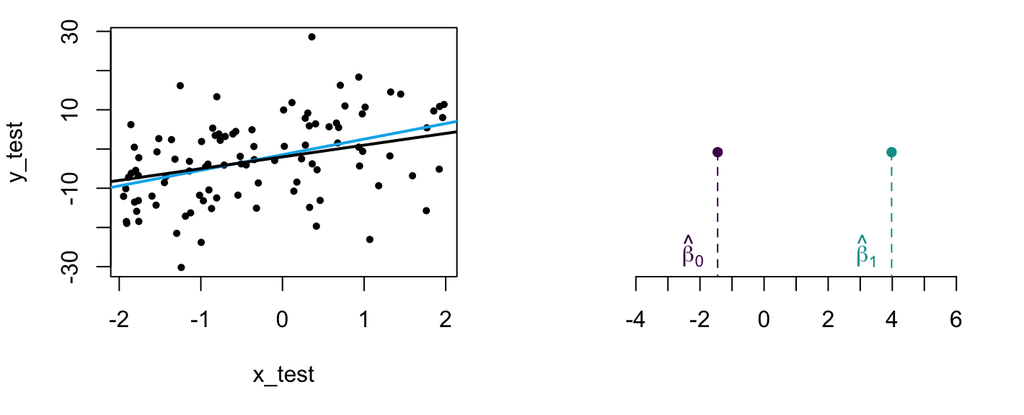

## Simulated dataset : replicates

Simulate according to the model :
$$\mathbf{y} = -2 \cdot \mathbb{1} + 3 \cdot \mathbf{x} + \boldsymbol{\epsilon}$$

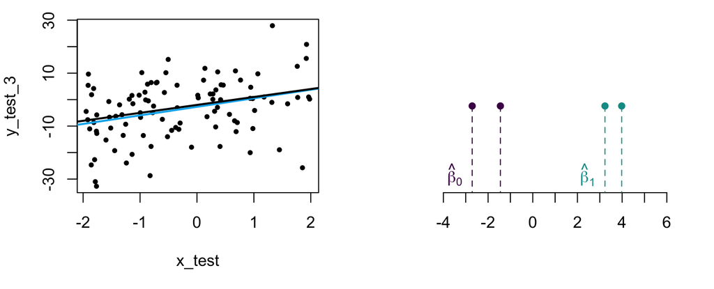

## Simulated dataset : replicates

Simulate according to the model :
$$\mathbf{y} = -2 \cdot \mathbb{1} + 3 \cdot \mathbf{x} + \boldsymbol{\epsilon}$$

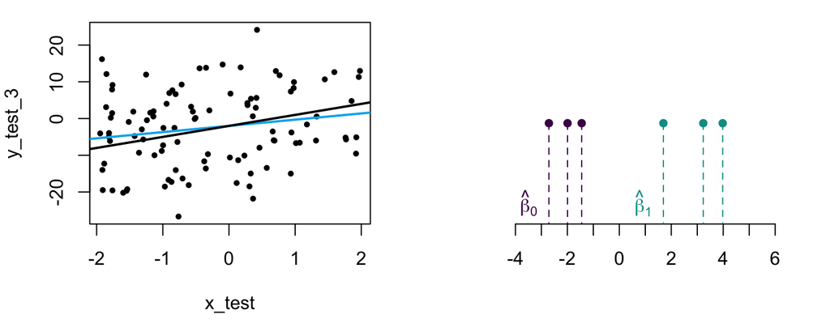

## Simulated dataset : replicates

Simulate according to the model :
$$\mathbf{y} = -2 \cdot \mathbb{1} + 3 \cdot \mathbf{x} + \boldsymbol{\epsilon}$$

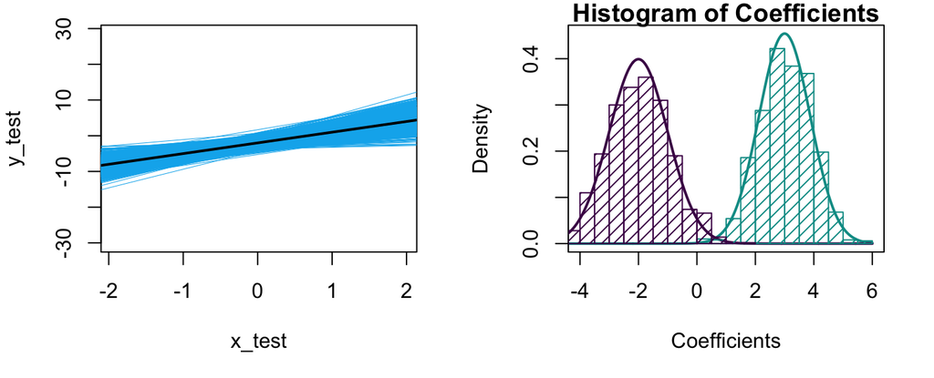

$$\hat{\beta}_0 \sim \mathcal{N}\left(\beta_0, \frac{\sigma^2}{n}\left(1 + \frac{\bar{x}^2}{s_{\mathbf{x}}^2}\right)\right)
\quad
\hat{\beta}_1 \sim \mathcal{N}\left(\beta_1, \frac{\sigma^2}{n}\frac{1}{s_{\mathbf{x}}^2}\right)$$

# Distribution of the Variance - $\sigma^2$ known

## Unbiased estimator of the Variance

$$\hat{\sigma}^2 = \frac{1}{n-2}\sum_{i = 1}^n \hat{\epsilon}_i^2
\qquad
\mathbb{E}[\hat{\sigma}^2] = \sigma^2$$

- **Question**: Distribution of $\hat{\sigma}^2$ ?

## Distribution of $\hat{\sigma}^2$

$$\frac{n-2}{\sigma^2}\hat{\sigma}^2 \sim \chi^2_{n-2}$$

- The variance estimator $\hat{\sigma}^2$ is distributed according to a **chi squared** distribution with **n-2** degrees of freedom.
- $\hat{\beta}$ and $\hat{\sigma}^2$ are **independent**.
- Proof delayed to next chapter (multivariate regression).

## Reminder: Chi Squared Distribution 1/3

Let $X_1, \dotsc, X_p$ be $p$ standard normal iid rv : $X_i \sim \mathcal{N}(0, 1)$. Then
$$X = \sum_{i = 1}^p X_i^2 \sim \chi^2_p$$

is a Chi squared r.v. with $p$ degrees of freedom.

We have:
$$\mathbb{E}[X] = p
\quad
\mathbb{Var}[X] = 2p.$$

It converges in distribution towards the Gaussian with matching moments.

## Reminder: Chi Squared Distribution 2/3

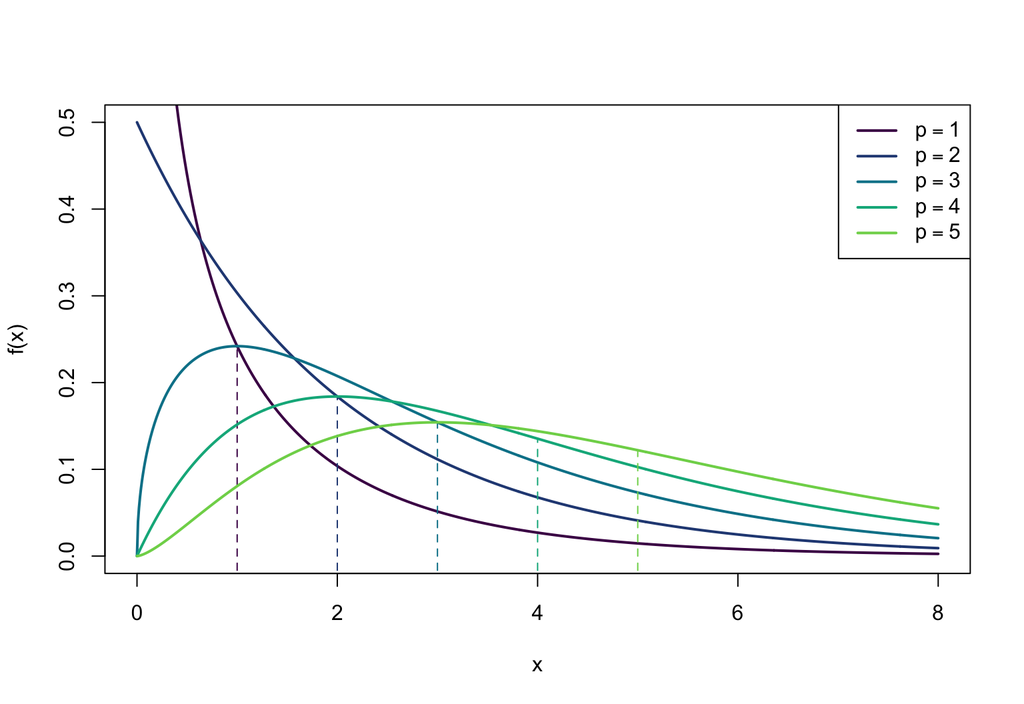

## Reminder: Chi Squared Distribution 3/3

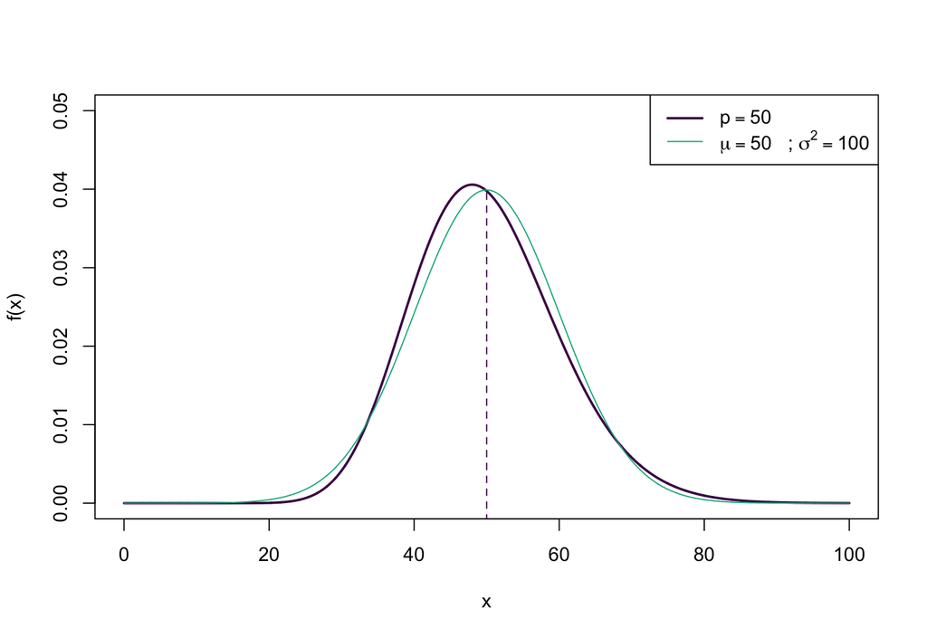

# Distribution of the Coefficients - $\sigma^2$ unknown

## Distribution of $(\hat{\beta}_0, \hat{\beta}_1)$

When $\sigma^2$ is known:

$$\begin{pmatrix}
\hat{\beta}_0 \\
\hat{\beta}_1
\end{pmatrix}
\sim
\mathcal{N}\left(
\begin{pmatrix}
\beta_0\\
\beta_1
\end{pmatrix};
\sigma^2 \mathbf{V}_n
\right)
\qquad
\mathbf{V}_n= \frac{1}{n}
\begin{pmatrix}
1 + \frac{\bar{x}^2}{s_{\mathbf{x}}^2} & -\frac{\bar{x}}{s_{\mathbf{x}}^2}\\
-\frac{\bar{x}}{s_{\mathbf{x}}^2} & \frac{1}{s_{\mathbf{x}}^2}
\end{pmatrix}$$

i.e.

$$\frac{\hat{\beta}_0 - \beta_0}{\sqrt{\sigma^2(1 + \bar{x}^2/s_{\mathbf{x}}^2)/n}}
\sim
\mathcal{N}(0, 1)
\qquad
\frac{\hat{\beta}_1 - \beta_1}{\sqrt{\sigma^2(1/s_{\mathbf{x}}^2)/n}}
\sim
\mathcal{N}(0, 1)$$

- **Problem** $\sigma^2$ is generally *unknown*.
- **Solution** Replace $\sigma^2$ by $\hat{\sigma}^2$.
- How is the distribution changed ?

## Distribution of $(\hat{\beta}_0, \hat{\beta}_1)$

When $\sigma^2$ is known:

$$\frac{\hat{\beta}_0 - \beta_0}{\sqrt{\sigma^2(1 + \bar{x}^2/s_{\mathbf{x}}^2)/n}}
\sim
\mathcal{N}(0, 1)
\qquad
\frac{\hat{\beta}_1 - \beta_1}{\sqrt{\sigma^2(1/s_{\mathbf{x}}^2)/n}}
\sim
\mathcal{N}(0, 1)$$

When $\sigma^2$ is **unknown**:
$$\frac{\hat{\beta}_0 - \beta_0}{\sqrt{\hat{\sigma}^2(1 + \bar{x}^2/s_{\mathbf{x}}^2)/n}}
\sim
\mathcal{T}_{n-2}
\qquad
\frac{\hat{\beta}_1 - \beta_1}{\sqrt{\hat{\sigma}^2(1/s_{\mathbf{x}}^2)/n}}
\sim
\mathcal{T}_{n-2}$$

- Replace standard Gaussian by **Student** distribution.

## Reminder: Student Distribution 1/2

Let $Z$ be a standard normal rv : $Z \sim \mathcal{N}(0, 1)$,
and $X$ a chi squared rv with $p$ degrees of freedom: $X \sim \chi^2_p$, $Z$ and $X$ independent. Then
$$T = \frac{Z}{\sqrt{X/p}} \sim \mathcal{T}_p$$

is a Student r.v. with $p$ degrees of freedom.

We have (for $p > 2$):
$$\mathbb{E}[T] = 0
\quad
\mathbb{Var}[T] = \frac{p}{p-2}.$$

It converges in distribution towards the standard Gaussian.

## Reminder: Student Distribution 2/2

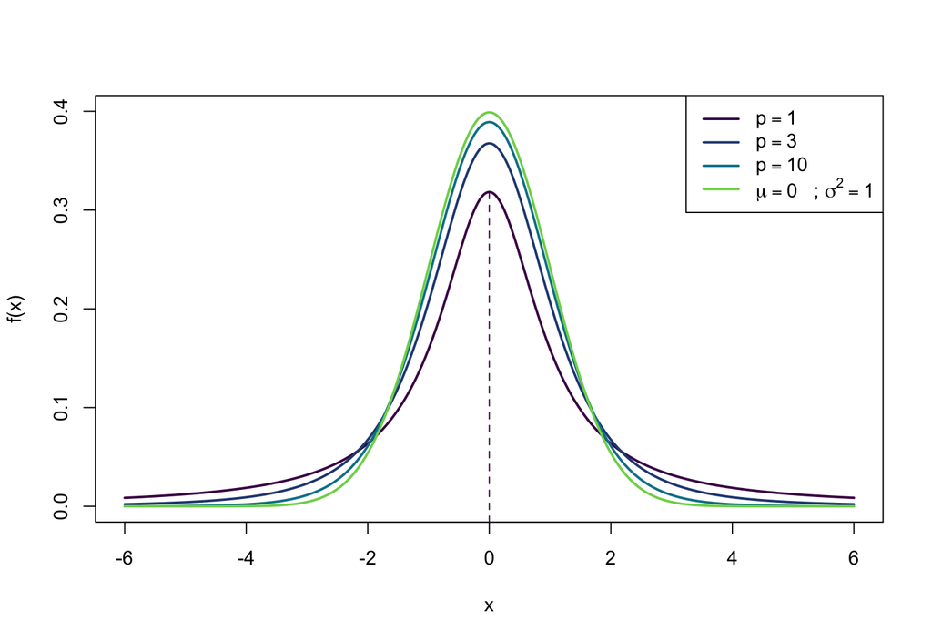

# Confidence Intervals

## Confidence intervals

$$\frac{\hat{\beta}_0 - \beta_0}{\sqrt{\hat{\sigma}^2_0}}
\sim
\mathcal{T}_{n-2}
\qquad
\frac{\hat{\beta}_1 - \beta_1}{\sqrt{\hat{\sigma}^2_1}}
\sim
\mathcal{T}_{n-2}\\
\frac{n-2}{\sigma^2}\hat{\sigma}^2 \sim \chi^2_{n-2}$$

- With probability $1-\alpha$:
  $$\begin{aligned}
  \beta_0 &\in \left[\hat{\beta}_0 \pm t_{n-2}(1 - \alpha/2) \sqrt{\hat{\sigma}_0^2}\right]\\
  \beta_1 &\in \left[\hat{\beta}_1 \pm t_{n-2}(1 - \alpha/2) \sqrt{\hat{\sigma}_1^2}\right]\\
  \sigma^2 &\in \left[\frac{(n-2)\hat{\sigma}^2}{c_{n-2}(1 - \alpha/2)}; \frac{(n-2)\hat{\sigma}^2}{c_{n-2}(\alpha/2)}\right]
  \end{aligned}$$

## Simulated dataset

$$\mathbf{y} = -2 \cdot \mathbb{1} + 3 \cdot \mathbf{x} + \boldsymbol{\epsilon}$$

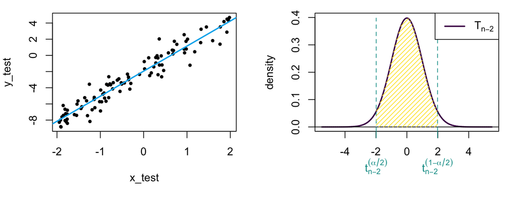

- With probability $1-\alpha$:
  $$\begin{aligned}
  t_{n-2}(\alpha/2) \leq \frac{\hat{\beta}_1 - \beta_1}{\sqrt{\hat{\sigma}^2_1}} \leq t_{n-2}(1 - \alpha/2)
  \end{aligned}$$

## Simulated dataset - `R` output

$$\mathbf{y} = -2 \cdot \mathbb{1} + 3 \cdot \mathbf{x} + \boldsymbol{\epsilon}$$

```r
linreg <- lm(y_test ~ x_test)
summary(linreg)
```

```
Call:
lm(formula = y_test ~ x_test)

Residuals:
     Min       1Q   Median       3Q      Max
-2.58688 -0.66510  0.05019  0.69597  2.86079

Coefficients:
            Estimate Std. Error t value Pr(>|t|)
(Intercept)  -1.9448     0.1017  -19.12   <2e-16 ***
x_test        3.0979     0.0866   35.77   <2e-16 ***
---
Signif. codes:  0 '***' 0.001 '**' 0.01 '*' 0.05 '.' 0.1 ' ' 1

Residual standard error: 0.9812 on 98 degrees of freedom
Multiple R-squared:  0.9289,    Adjusted R-squared:  0.9281
F-statistic:  1280 on 1 and 98 DF,  p-value: < 2.2e-16
```

# Prediction Intervals

## Prediction error

Recall that the prediction error $\hat{\epsilon}_{n+1} = y_{n+1} - \hat{y}_{n+1}$ is such that:
$$\begin{aligned}
\mathbb{E}[\hat{\epsilon}_{n+1}] &= 0\\
\mathbb{Var}[\hat{\epsilon}_{n+1}] &= \sigma^2 \left(1 + \frac{1}{n} + \frac{1}{ns_{\mathbf{x}}^2} (x_{n+1} - \bar{x})^2\right)\\
\end{aligned}$$

## Prediction Distribution

We get (variance known):

$$y_{n+1} - \hat{y}_{n+1}
\sim
\mathcal{N}\left(0, \sigma^2 \left(1 + \frac{1}{n} + \frac{1}{ns_{\mathbf{x}}^2} (x_{n+1} - \bar{x})^2\right)\right)$$

and (variance unknown):
$$\frac{y_{n+1} - \hat{y}_{n+1}}{\sqrt{\hat{\sigma}^2 \left(1 + \frac{1}{n} + \frac{1}{ns_{\mathbf{x}}^2} (x_{n+1} - \bar{x})^2\right)}}
\sim
\mathcal{T}_{n-2}$$

# Advertising Dataset

## Advertising

```r
library(here)
ad <- read.csv(here("data", "Advertising.csv"), row.names = "X")
head(ad)
```

```
     TV radio newspaper sales
1 230.1  37.8      69.2  22.1
2  44.5  39.3      45.1  10.4
3  17.2  45.9      69.3   9.3
4 151.5  41.3      58.5  18.5
5 180.8  10.8      58.4  12.9
6   8.7  48.9      75.0   7.2
```

- `TV`, `radio`, `newspaper`: advertising budgets (thousands of $)
- `sales`: number of sales (thousands of units)

## Advertising - TV - 1/6

```r
fit_tv <- lm(sales ~ TV, data = ad)
plot(ad$TV, ad$sales)
abline(fit_tv, col = "blue")
```

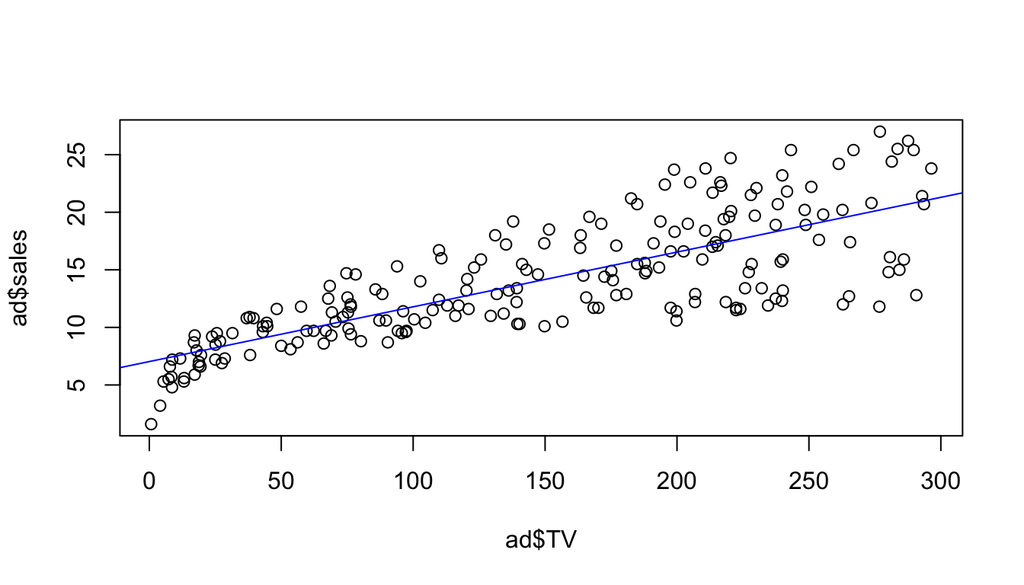

## Advertising - TV - 2/6

```r
summary(fit_tv)
```

```
Call:
lm(formula = sales ~ TV, data = ad)

Residuals:
    Min      1Q  Median      3Q     Max
-8.3860 -1.9545 -0.1913  2.0671  7.2124

Coefficients:
            Estimate Std. Error t value Pr(>|t|)
(Intercept) 7.032594   0.457843   15.36   <2e-16 ***
TV          0.047537   0.002691   17.67   <2e-16 ***
---
Signif. codes:  0 '***' 0.001 '**' 0.01 '*' 0.05 '.' 0.1 ' ' 1

Residual standard error: 3.259 on 198 degrees of freedom
Multiple R-squared:  0.6119,    Adjusted R-squared:  0.6099
F-statistic: 312.1 on 1 and 198 DF,  p-value: < 2.2e-16
```

## Advertising - TV - 3/6

- Is there a relationship between TV advertising budget and sale ?
  - Student t test: p values < 2e-16
- How strong is the relationship ?
  - RSS = 3.259, RSS / $\bar{y}$ = 23% (rough percentage of error)
  - $R^2$: 0.6119 : Only around 61% of the variance explained.
- How large is the effect of TV on sales ?
  - $\hat{\beta}_1 \approx 0.047537 \pm 1.96 \times 0.002691$
  - CI away from 0
  - When I spend 1000$ more in TV, I sell about 47.5 more units.

## Advertising - TV - 4/6

```r
## lm fit
fit_tv <- lm(sales ~ TV, data = ad)
plot(ad$TV, ad$sales)
abline(fit_tv, col = "black")
## colors
contrast_col <- hcl.colors(2)
## Confidence interval
newx <- seq(0, 300, by = 1)
conf_int <- predict(fit_tv, data.frame(TV = newx), interval = "conf")
# Plot
lines(newx, conf_int[, 2], col = contrast_col[1], lty = 2, lwd = 2)
lines(newx, conf_int[, 3], col = contrast_col[1], lty = 2, lwd = 2)
# Prediction intervals
pred_int <- predict(fit_tv, data.frame(TV = newx), interval = "pred")
# Plot
lines(newx, pred_int[, 2], col = contrast_col[2], lty = 2, lwd = 2)
lines(newx, pred_int[, 3], col = contrast_col[2], lty = 2, lwd = 2)
```

## Advertising - TV - 5/6

- 95% confidence interval (dark purple) and prediction interval (light yellow)

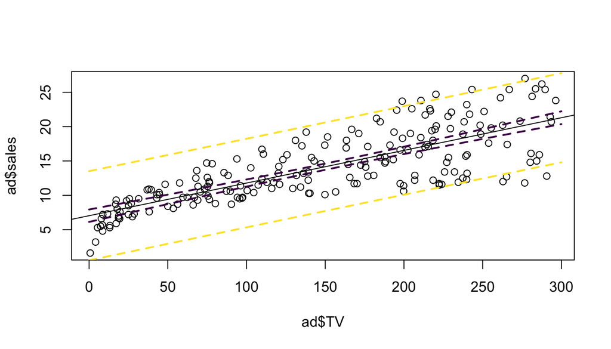

## Advertising - TV - 6/6

- How accurately can we predict future sales ?
  - See prediction intervals
- Is the relationship linear ?
  - Does it look like it ? More on that later.
- Which media contribute to sales ?
  - Start again with newspapers and radio.
- Is there synergy among the media ?
  - ??
- To answer these questions better, we need **multiple** linear regression.
  - Next chapter.

# Joint Distribution of the Coefficients - $\sigma^2$ unknown

## Distribution of $(\hat{\beta}_0, \hat{\beta}_1)$

When $\sigma^2$ is known:

$$\hat{\boldsymbol{\beta}} =
\begin{pmatrix}
\hat{\beta}_0 \\
\hat{\beta}_1
\end{pmatrix}
\sim
\mathcal{N}\left(
\boldsymbol{\beta} =
\begin{pmatrix}
\beta_0\\
\beta_1
\end{pmatrix};
\sigma^2 \mathbf{V}_n
\right)$$

When $\sigma^2$ is **unknown**:
$$\frac{1}{2\hat{\sigma}^2}\left(\hat{\boldsymbol{\beta}} - \boldsymbol{\beta}\right)^T \mathbf{V}_n^{-1}\left(\hat{\boldsymbol{\beta}} - \boldsymbol{\beta}\right)
\sim
\mathcal{F}^2_{n-2}$$

- with $\mathcal{F}^2_{n-2}$ the **Fisher** distribution.

## Reminder: Fisher Distribution 1/2

Let $U_1 \sim \chi^2_{p_1}$ and $U_2 \sim \chi^2_{p_2}$, $U_1$ and $U_2$ independent. Then
$$F = \frac{U_1/p_1}{U_2/p_2} \sim \mathcal{F}^{p_1}_{p_2}$$

is a Fisher r.v. with $(p_1, p_2)$ degrees of freedom.

We have (for $p_2 > 2$):
$$\mathbb{E}[F] = \frac{p_2}{p_2 - 2}.$$

When $p_2$ goes to infinity, $\mathcal{F}^{p_1}_{p_2}$ converges in distribution to $\frac{1}{p_1}\chi^2_{p_1}$.

## Reminder: Fisher Distribution 2/2

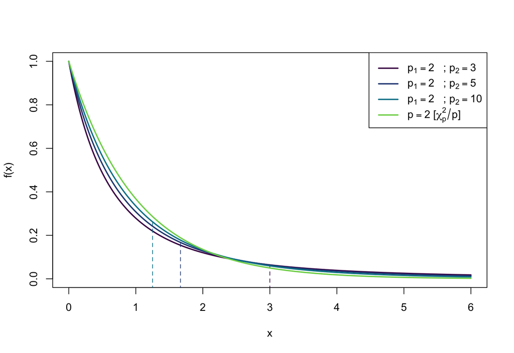

# Confidence Region

## Confidence Intervals

- Marginal distributions:

$$\frac{\hat{\beta}_0 - \beta_0}{\sqrt{\hat{\sigma}^2_0}}
\sim
\mathcal{T}_{n-2}
\qquad
\frac{\hat{\beta}_1 - \beta_1}{\sqrt{\hat{\sigma}^2_1}}
\sim
\mathcal{T}_{n-2}$$

- Give confidence intervals:

$$\begin{aligned}
\beta_0 &\in \left[\hat{\beta}_0 \pm t_{n-2}(1 - \alpha/2) \sqrt{\hat{\sigma}_0^2}\right]\\
\beta_1 &\in \left[\hat{\beta}_1 \pm t_{n-2}(1 - \alpha/2) \sqrt{\hat{\sigma}_1^2}\right]\\
\end{aligned}$$

## Confidence Region

- Joint distribution:

$$\frac{1}{2\hat{\sigma}^2}\left(\hat{\boldsymbol{\beta}} - \boldsymbol{\beta}\right)^T \mathbf{V}_n^{-1}\left(\hat{\boldsymbol{\beta}} - \boldsymbol{\beta}\right)
\sim
\mathcal{F}^2_{n-2}$$

- Gives confidence region:

$$\frac{1}{2\hat{\sigma}^2}\left(\hat{\boldsymbol{\beta}} - \boldsymbol{\beta}\right)^T \mathbf{V}_n^{-1}\left(\hat{\boldsymbol{\beta}} - \boldsymbol{\beta}\right)
\leq
f_{n-2}^2(1 - \alpha)$$

Since $\mathbf{V}_n^{-1}$ is positive definite, this is the equation of an elliptic region.

## Simulated dataset

$$\mathbf{y} = -2 \cdot \mathbb{1} + 3 \cdot \mathbf{x} + \boldsymbol{\epsilon}$$

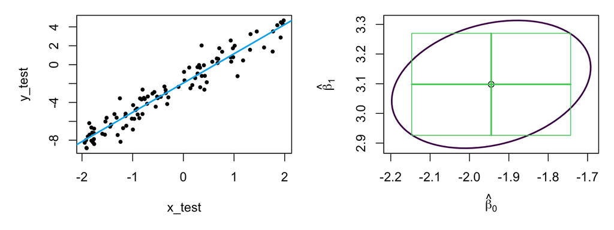

Difference between:

- **confidence intervals** (green) and the
- **confidence region** (purple).